# R Task

Leonard Reidel

30 5 2020

```r
#Include necessary packages
library(data.table)
library(stringr)
library(ggplot2)

#Load data set
data_set <- esoph
#Convert data.frame to data.table
setDT(data_set)
```

# R Task

## Check data

The esoph data set contains the data of a case-control study about (o)esophageal cancer and its relationship to alcohol and tobacco consumptionn in Ille-et-Vilaine, France.

Take a look at the first 6 rows to get an overview.

```r
head(data_set)
```

```
##    agegp     alcgp    tobgp ncases ncontrols
## 1: 25-34 0-39g/day 0-9g/day      0        40
## 2: 25-34 0-39g/day    10-19      0        10
## 3: 25-34 0-39g/day    20-29      0         6
## 4: 25-34 0-39g/day      30+      0         5
## 5: 25-34     40-79 0-9g/day      0        27
## 6: 25-34     40-79    10-19      0         7
```

Check the structure of the data.

```r
str(data_set)
```

```
## Classes 'data.table' and 'data.frame':   88 obs. of  5 variables:
##  $ agegp    : Ord.factor w/ 6 levels "25-34"<"35-44"<..: 1 1 1 1 1 1 1 1 1 1 ...
##  $ alcgp    : Ord.factor w/ 4 levels "0-39g/day"<"40-79"<..: 1 1 1 1 2 2 2 2 3 3 ...
##  $ tobgp    : Ord.factor w/ 4 levels "0-9g/day"<"10-19"<..: 1 2 3 4 1 2 3 4 1 2 ...
##  $ ncases   : num  0 0 0 0 0 0 0 0 0 0 ...
##  $ ncontrols: num  40 10 6 5 27 7 4 7 2 1 ...
##  - attr(*, ".internal.selfref")=<externalptr>
```

The data containns 88 combinations of the age group (agegp), the alcohol consumption in g/day (alcgp), and the tobacco consumption (tobgp). ncases indicates the number of patients with (o)esophageal cancer in the respective groups and ncontrols indicates the number of controls (no cancer) in the respective group.

Look at the summary of the data

```r
#Call summary function to get overview
summary(data_set)
```

```
##    agegp          alcgp         tobgp        ncases         ncontrols
##  25-34:15   0-39g/day:23   0-9g/day:24   Min.   : 0.000   Min.   : 1.00
##  35-44:15   40-79    :23   10-19   :24   1st Qu.: 0.000   1st Qu.: 3.00
##  45-54:16   80-119   :21   20-29   :20   Median : 1.000   Median : 6.00
##  55-64:16   120+     :21   30+     :20   Mean   : 2.273   Mean   :11.08
##  65-74:15                                3rd Qu.: 4.000   3rd Qu.:14.00
##  75+  :11                                Max.   :17.000   Max.   :60.00
```

In mean, we have 2.273 cancer cases per category and 11.08 control patients.

Get the total number of controls and the total number of cases.

```r
#Print the sum number of patients, the number of patients with cancer and the number of control patients respectively
#Concatenate string with paste in order to get a decently formatted output and print it
print(paste0("Total number of patients: ", sum(data_set$ncases) + sum(data_set$ncontrols)))
```

```
## [1] "Total number of patients: 1175"
```

```r
print(paste0("Total number of cancer cases: ", sum(data_set$ncases)))
```

```
## [1] "Total number of cancer cases: 200"
```

```r
print(paste0("Total number of controls: ", sum(data_set$ncontrols)))
```

```
## [1] "Total number of controls: 975"
```

```r
#Remove g/day from strings

#For alcgp
data_set[, alcgp := gsub(pattern = "g/day", replacement = "", x = alcgp)]
#For tobgp
data_set[, tobgp := gsub(pattern = "g/day", replacement = "", x = tobgp)]

#gsub returns the elements as strings but before, the variables were ordered factors (see str()-call)
#Make both variables ordered factors again

#alcgp
data_set[, alcgp := factor(alcgp, ordered = TRUE, levels = c("0-39","40-79","80-119","120+"))]
data_set[, tobgp := factor(tobgp, ordered = TRUE, levels = c("0-9","10-19","20-29","30+"))]
```

## Age distributions

Check the distribution of ages among all patients. In order to do that, we first want to make a total_patients column containing the total number of people (cases + controls), who were participating in the study.

```r
#Create total_patients column
data_set[, total_patients := ncases + ncontrols]
```

Now, vizualize the data in a bar plot, using the ggplot2-library. To do that, we first have to group the data by age groups and sum up the total patients column.

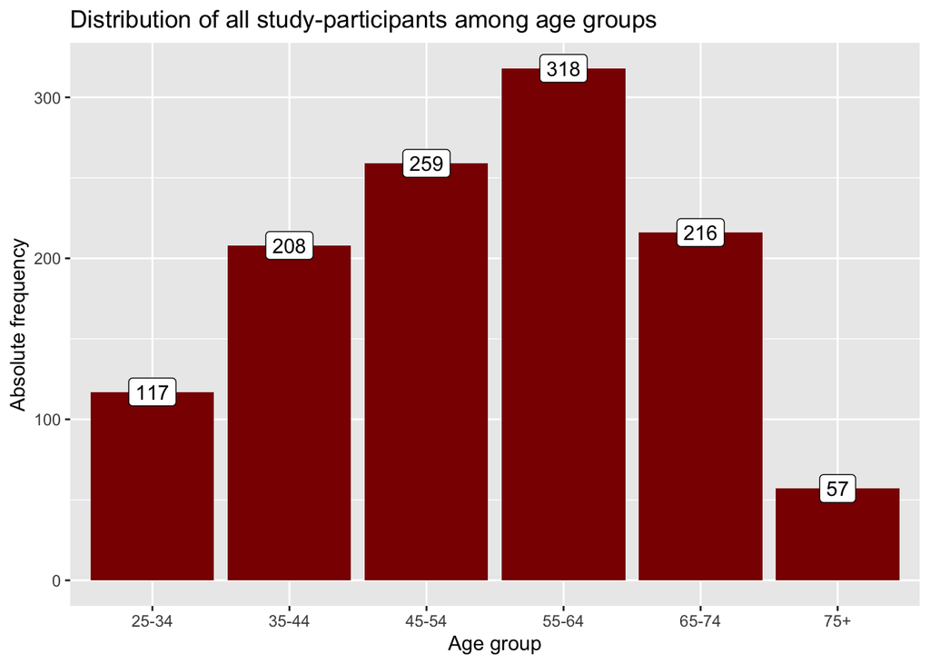

```r
data_set_grouped_age <- data_set[,list(total_patients = sum(total_patients)), by = "agegp"]

#Plot absolute frequency per age group
ggplot(data_set_grouped_age, aes(x = agegp, y = total_patients)) +
  geom_bar(stat = "identity", fill = "darkred")+
  geom_label(aes(label = total_patients))+
  labs(x = "Age group", y = "Absolute frequency", title = "Distribution of all study-participants among age groups")
```

Most of the participats are between 55 and 64 years old. With only 57 participants, the 75+-group is very sparsely populated.

In order to find out if the distribution varies between positive and negative cancer cases, we want to make a grouped bar chart vizualizing the number of positive and negative cancer cases by age group.

In order to do that, we have to group the data again by age group and sum up cancer and non-cancer cases respectively. After that, we transform the data to the long-format with the melt function in order to serve as a valid input for ggplot.

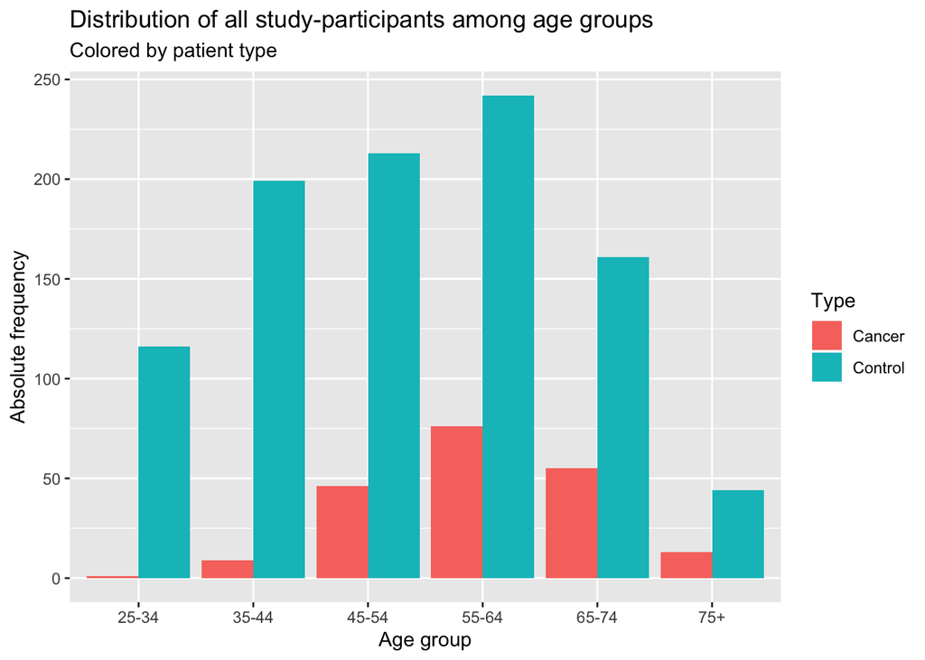

```r
data_set_grouped_age <- data_set[,list(Cancer = sum(ncases),
                                       Control = sum(ncontrols)), by = "agegp"]


#Transoform to long-format using melt
#The id-variable is age and the 2 measure-variables are Cancer and Control
data_set_grouped_age <- melt(data_set_grouped_age,
                             id.vars = "agegp",
                             measure.vars = c("Cancer","Control"),
                             variable.name = "Type",
                             value.name = "Frequency")

#Plot absolute frequency per age group and group
ggplot(data_set_grouped_age, aes(x = agegp, y = Frequency, fill = Type)) +
  geom_bar(stat = "identity",position =  "dodge") +  #Use position = "dodge" to tell ggplot to group the bars rather than stacking them
  labs(x = "Age group",
       y = "Absolute frequency",
       title = "Distribution of all study-participants among age groups",
       subtitle = "Colored by patient type")
```

As expected, cancer seems to be more prevalent among older age groups. But the different scales between study- and control group make it hard to identify if there’s a structural difference. User facet_wrap, to make a group of plots with an own scale each

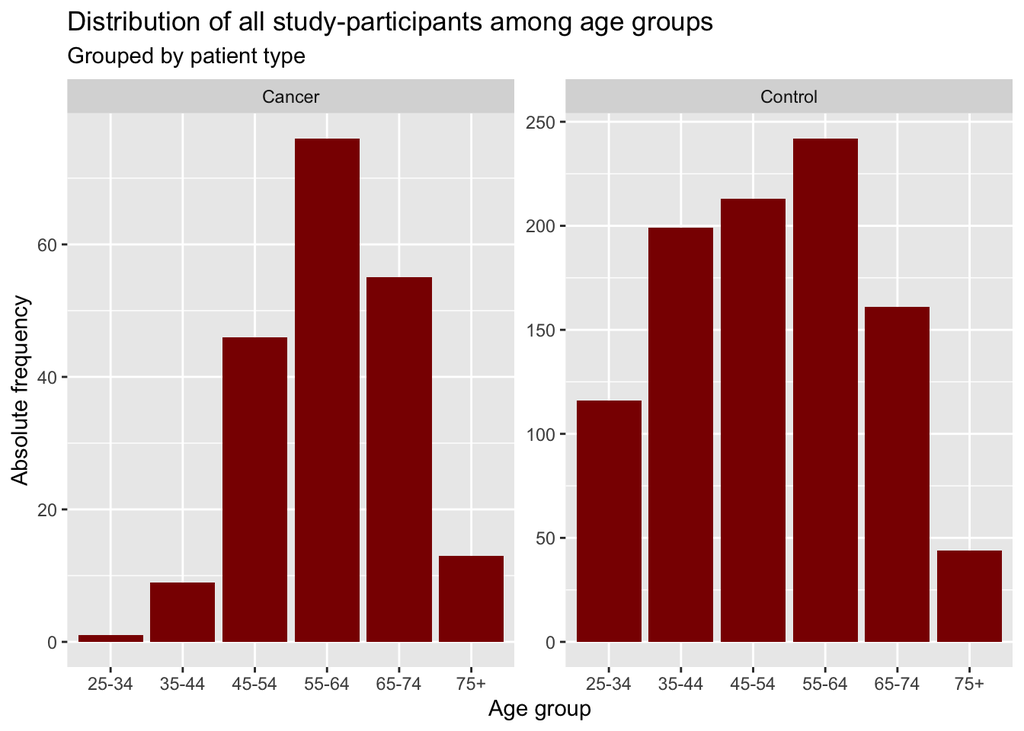

```r
#Plot absolute frequency per age group and group
ggplot(data_set_grouped_age, aes(x = agegp, y = Frequency)) +
  geom_bar(stat = "identity", fill = "darkred") +  #Use position = "dodge" to tell ggplot to group the bars rather than stacking them
  labs(x = "Age group",
       y = "Absolute frequency",
       title = "Distribution of all study-participants among age groups",
       subtitle = "Grouped by patient type")+
  facet_wrap(Type~., scales = "free_y")
```

Now one can clearly see that there are almost no cancer cases among younger age groups (<45), but they rapidly rise among older patients.

To check this one last time, we plot the relative frequency of cancer by age group.

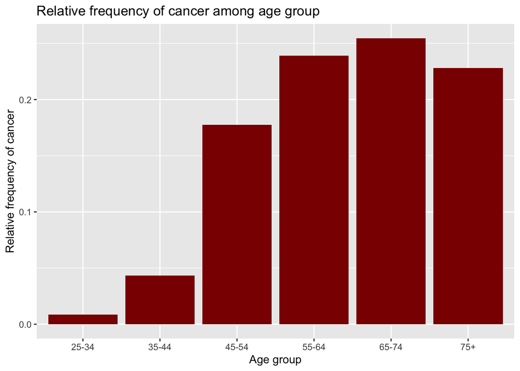

```r
#Group by age
data_set_groupd_age_rel <- data_set[, list(ncases = sum(ncases),
                                       total_patients = sum(total_patients)),
                                by = "agegp"]

#Add column with relative frequency of cancer
data_set_groupd_age_rel[, rel_frequ := ncases/total_patients]


#Plot relative frequency of cancer
ggplot(data_set_groupd_age_rel, aes(x = agegp, y = rel_frequ)) +
  geom_bar(stat = "identity", fill = "darkred") +  #Use position = "dodge" to tell ggplot to group the bars rather than stacking them
  labs(x = "Age group",
       y = "Relative frequency of cancer",
       title = "Relative frequency of cancer among age group")
```

Now one can clearly see the rise in cancer frequency going towards higher ages.

## Check relation to tobacco and alcohol

First check the general distribution of alcohol & tobacco consumption among all cases.

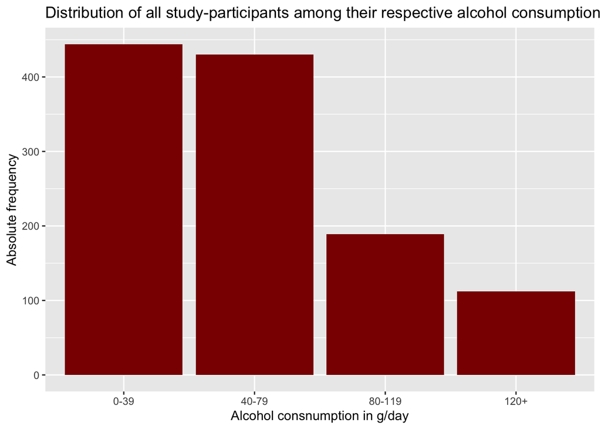

```r
#Group by alcohol consumption
data_set_groupd_alc <- data_set[, list(total_patients = sum(total_patients)),
                                by = "alcgp"]



#Plot abs. frequency
ggplot(data_set_groupd_alc, aes(x = alcgp, y = total_patients)) +
  geom_bar(stat = "identity", fill = "darkred") +
  labs(x = "Alcohol consnumption in g/day",
       y = "Absolute frequency",
       title = "Distribution of all study-participants among their respective alcohol consumptions")
```

Most of the patients exhibit a relatively low alcohol consumtion of <80 g/day while a small portion exhihibts levels above 79

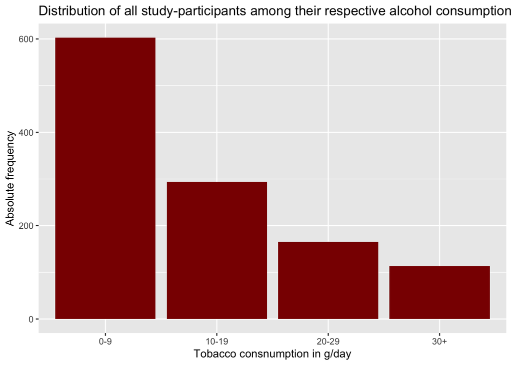

```r
#Group by tobacco consumption
data_set_groupd_tob <- data_set[, list(total_patients = sum(total_patients)),
                                by = "tobgp"]

#Plot abs. frequency
ggplot(data_set_groupd_tob, aes(x = tobgp, y = total_patients)) +
  geom_bar(stat = "identity", fill = "darkred") +
  labs(x = "Tobacco consnumption in g/day",
       y = "Absolute frequency",
       title = "Distribution of all study-participants among their respective alcohol consumptions")
```

Tobacco consumption shows a bit different picture. There’s a very large portion of participants consuming between 0 and 9 g/day while the other groups are still decreasing with consumption intensity but exhibit a generally much lower scale. That’s most likely due to the fact that we have a significant portion of non-smokers.

Next up, we want to see if there’s relationship between alcohol/tobacco consumption and the frequency of cancer. So we group the data by alcohol/tobacco consumption and check the rate of cancer and non-cancer cases.

First for alcohol:

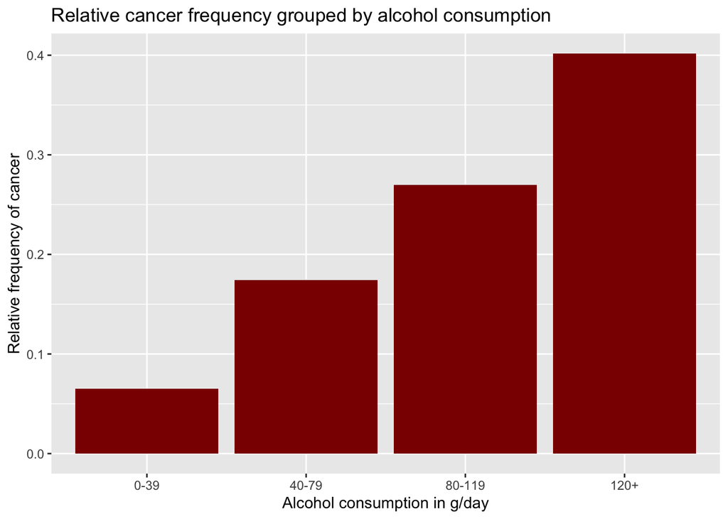

```r
#Group by alcohol consumption
data_set_groupd_alc_rel <- data_set[, list(ncases = sum(ncases),
                                       total_patients = sum(total_patients)),
                                by = "alcgp"]

#Add column with relative frequency of cancer
data_set_groupd_alc_rel[, cancer_freq := ncases/total_patients]


#Plot relative frequency of cancer
ggplot(data_set_groupd_alc_rel, aes(x = alcgp, y = cancer_freq)) +
  geom_bar(stat = "identity", fill = "darkred") +  #Use position = "dodge" to tell ggplot to group the bars rather than stacking them
  labs(x = "Alcohol consumption in g/day",
       y = "Relative frequency of cancer",
       title = "Relative cancer frequency grouped by alcohol consumption")
```

There’s a clear positive correlation in the relative frequency of cancer and alcohol consumption in the data set.

Now tobacco:

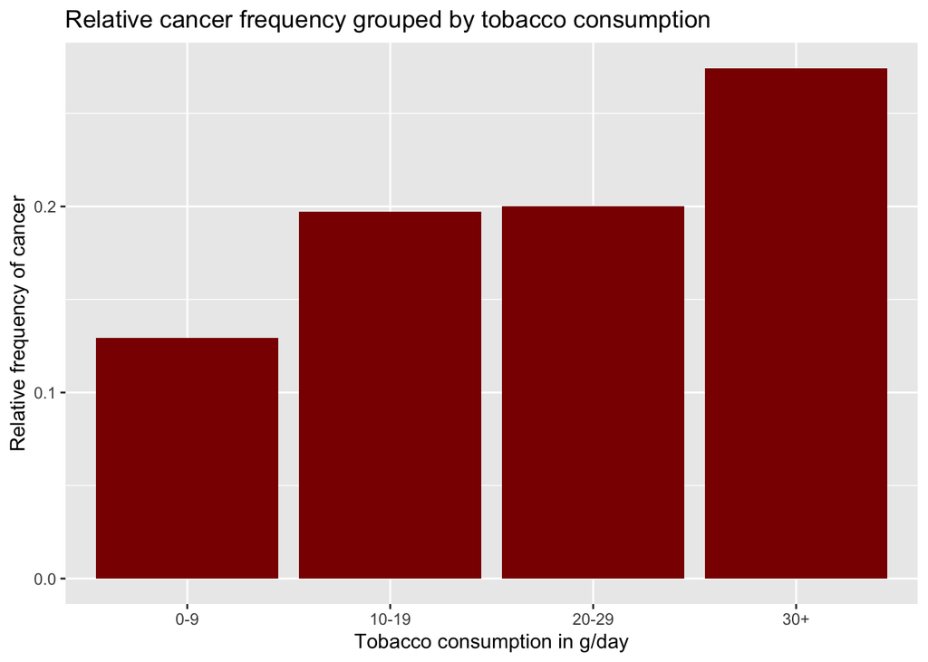

```r
#Group by alcohol consumption
data_set_groupd_tob_rel <- data_set[, list(ncases = sum(ncases),
                                       total_patients = sum(total_patients)),
                                by = "tobgp"]

#Add column with relative frequency of cancer
data_set_groupd_tob_rel[, cancer_freq := ncases/total_patients]


#Plot relative frequency of cancer
ggplot(data_set_groupd_tob_rel, aes(x = tobgp, y = cancer_freq)) +
  geom_bar(stat = "identity", fill = "darkred") +  #Use position = "dodge" to tell ggplot to group the bars rather than stacking them
  labs(x = "Tobacco consumption in g/day",
       y = "Relative frequency of cancer",
       title = "Relative cancer frequency grouped by tobacco consumption")
```

The relationship doesn’t seem as strong as with alcohol but nevertheless, one can see a rise in cancer frequency with the rise of tobacco consumption.

Finally, we want to see how both consumptions affect cancer frequency simultaneously. In order to do that, we draw a heatmap.

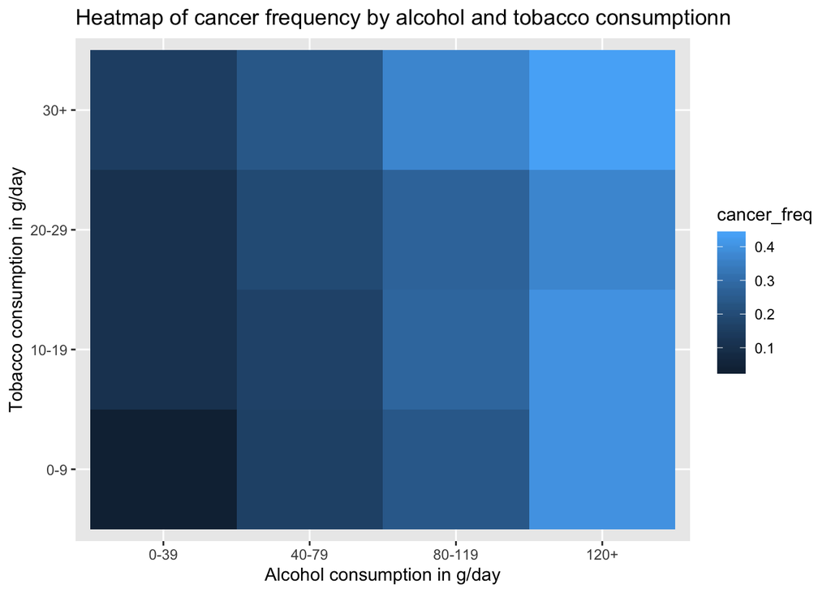

```r
#Group by alcohol consumption
data_set_groupd_total_rel <- data_set[, list(ncases = sum(ncases),
                                       total_patients = sum(total_patients)),
                                by = c("alcgp","tobgp")]

#Add column with relative frequency of cancer
data_set_groupd_total_rel[, cancer_freq := ncases/total_patients]


#Plot relative frequency of cancer
ggplot(data_set_groupd_total_rel, aes(x = alcgp, y = tobgp, fill = cancer_freq)) +
  geom_tile() +  #Use position = "dodge" to tell ggplot to group the bars rather than stacking them
  labs(x = "Alcohol consumption in g/day",
       y = "Tobacco consumption in g/day",
       title = "Heatmap of cancer frequency by alcohol and tobacco consumptionn")
```

Not surprisingly, the cancer frequency drastically rises, with both alcohol ant tobacco consumption.